# Lab 5: Metropolis-Hastings algorithm

2022-07-15

```r
library(ggplot2)
```

## Summary

### Objective

Let our parameter of interest, $\theta$, have the following posterior pdf:
$$f(\theta | y) \propto f(\theta)L(\theta|y)$$

Likely the posterior is intractable (i.e. we cannot calculate it) so we want to approximate the posterior by *obtaining samples of our parameter of interest with the target distribution*. We use those samples to approximate the posterior distribution.

### Idea

- Start at some intial guess for $\theta$
- Draw a sample, $\theta'$, from a proposed model with a pdf, $q(\theta' | \theta)$, that we can easily sample from and is conditional on our guess for $\theta$.
- Calculate an acceptance probability $\alpha$ for this guess, which accounts for the posterior and proposal probabilities of both the guess $\theta$ and the new sample $\theta'$.
- Accept the proposed sample $\theta'$ according the the acceptance probability

### Algorithm

- **Step 1: Propose a new location.**  
  Conditioned on the current location $\theta$, draw a location $\theta'$ from a proposed model with pdf $q(\theta' | \theta)$.
- **Step 2: Decide whether or not to go there.**
  - Calculate the proposal acceptance probability:
    $$\alpha = min\{ 1, \frac{f(\theta')
    L(\theta' | y)}{f(\theta) L(\theta | y)} \frac{q(\theta |
    \theta')}{q(\theta' | \theta)}\}$$
  - Draw a Bernoulli random variable with acceptance probability $\alpha$. If successful store the proposed $\theta'$, if not store the original guess

## Normal-normal example

Now that we have our model lets code one run of this algorithm.

```r
set.seed(8)

# Set some initial guess for $mu$
current <- 3
# Set some step size
w <- 1

# Draw a proposal mu'
proposal <- runif(1, min = current - w, max = current + w)

# Calculate components of acceptance probability
proposal_f <- dnorm(proposal, mean = 0, sd = 1) * dnorm(6.25, proposal, 0.75)
proposal_q <- dunif(proposal, min = proposal - w, max = proposal + w)
current_f <- dnorm(current, 0, 1) * dnorm(6.25, current, 0.75)
current_q <- dunif(current, min = current - w, max = current + w)

# Calculate acceptance probability
alpha <- min(
  1,
  proposal_f * current_q / (current_f * proposal_q)
)

# Do a random draw to determine which sample of mu to keep
next_stop <- sample(
  c(proposal, current),
  size = 1,
  prob = c(alpha, 1 - alpha)
)
```

We now have the code for a single iteration of the Metropolis-Hastings algorithm. It returns one sample of $\mu$.

In practice we would want to obtain thousands of these samples so we can have a better understanding of the posterior distribution. Instead of copying and pasting this code repeatedly, we can make it into a function so we can perform an iteration of Metropolis-Hastings in one function call.

Note at the beginning of our code we set $\mu$ and $w$. We can make these arguments to our function so they are provided at each function call.

```r
one_mh_iteration <- function(current, w){

  # Draw a proposal mu'
  proposal <- runif(1, min = current - w, max = current + w)

  # Calculate components of acceptance probability
  proposal_f <- dnorm(proposal, mean = 0, sd = 1) * dnorm(6.25, proposal, 0.75)
  proposal_q <- dunif(proposal, min = proposal - w, max = proposal + w)
  current_f <- dnorm(current, 0, 1) * dnorm(6.25, current, 0.75)
  current_q <- dunif(current, min = current - w, max = current + w)

  # Calculate acceptance probability
  alpha <- min(
    1,
    proposal_f * current_q / (current_f * proposal_q)
  )

  # Do a random draw to determine which sample of mu to keep
  next_stop <- sample(
    c(proposal, current),
    size = 1,
    prob = c(alpha, 1 - alpha)
  )

  # Return the results
  return(
    data.frame(proposal, alpha, next_stop)
  )

}
```

Let’s call the function once to check.

```r
set.seed(8)

one_mh_iteration(current = 3, w = 1)
```

```
##   proposal     alpha next_stop
## 1  2.93259 0.8240205   2.93259
```

We now have the code to easily run an iteration. Let’s define a function which performs $N$ Metropolis-Hastings iterations.

```r
normal_mh_tour <- function(N, w){

  # Start the chain at this value
  current <- 3

  # Initialize a vector to store our samples of mu
  mu <- rep(NA, N)

  # Simulate N Markov chain stops
  for(i in 1:N){
    # Simulate on iteration
    sim <- one_mh_iteration(current = current, w = w)

    # Record new sample
    mu[i] <- sim$next_stop

    # Set new current sample
    current <- sim$next_stop
  }

  # Return the chain locations
  return(
    data.frame(iteration = 1:N, mu = mu)
  )
}
```

Let’s use our sampler now!

```r
set.seed(8)

mh_simulation_1 <- normal_mh_tour(N = 5000, w = 1)
```

Lastly, we will make a trace plot to assess how our sampling went and plot the distribution of our sampling.

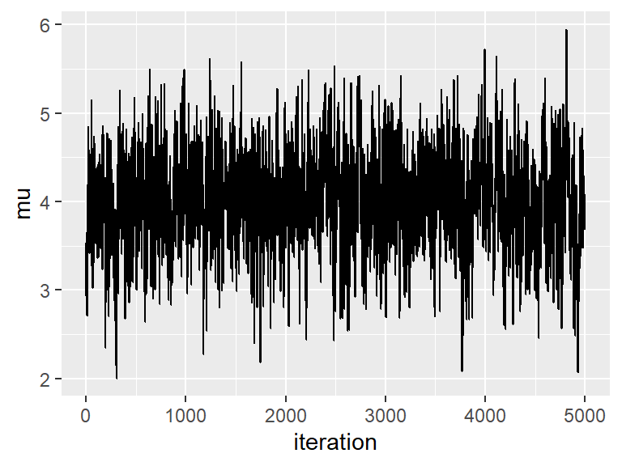

```r
ggplot(mh_simulation_1, aes(x = iteration, y = mu)) +
  geom_line()
```

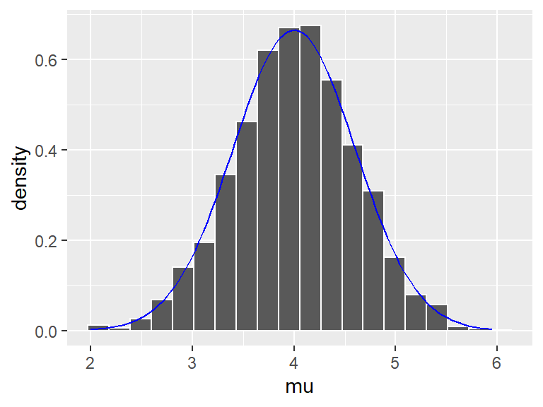

```r
ggplot(mh_simulation_1, aes(x = mu)) +
  geom_histogram(aes(y = ..density..), color = "white", bins = 20) +
  stat_function(fun = dnorm, args = list(4,0.6), color = "blue")
```

The blue curve is the actual posterior we were trying to simulate samples from.

We now have the framework for the Metropolis-Hastings (MH) algorithm, what would we need to change for a different model?

## Beta-Binomial model

In this example we will work with the Beta-Binomial model in which we observe $Y=1$ success in 2 trials:
$$\pi \sim Beta(2, 3) \\ Y|\pi \sim Bin(2,
\pi).$$

We are simulation probabilities in this case so we need a proposal with support between 0 and 1. We will choose a $Beta(a, b)$ as the proposal distribution.

Below is the framework for defining one MH iteration, fill it in for this model.

```r
one_iteration <- function(current, a, b){
  # Draw a proposal pi'


  # Calculate components of acceptance probability


  # Calculate acceptance probability


  # Do a random draw to determine which sample of pi to keep


  # Return the results
  return(
    data.frame(proposal, alpha, next_stop)
  )

}
```

Next we need the overall function that obtains $N$ samples. Again fill in the framework provided.

```r
beta_bin_mh_tour <- function(N, a, b){

  # Start the chain at 0.5


  # Initialize a vector to store our samples of pi


  # Simulate N Markov chain stops
  for(i in 1:N){
    # Simulate on iteration


    # Record new sample


    # Set new current sample


  }

  # Return the chain locations
  return(
    data.frame(iteration = 1:N, pi = pi)
  )

}
```

Run your code to obtain 5000 samples of $\pi$. Once your code is read remove “eval = FALSE” from the code chunk header in order to run the code below.

```r
set.seed(84735)
betabin_sim <- beta_bin_mh_tour(N = 5000, a = 1, b = 1)

# Plot the results
ggplot(betabin_sim, aes(x = iteration, y = pi)) +
  geom_line()

ggplot(betabin_sim, aes(x = pi)) +
  geom_histogram(aes(y = ..density..), color = "white") +
  stat_function(fun = dbeta, args = list(3, 4), color = "blue")
```